# Fuel Economy Data Analysis

*- By Maithili Desai*

## Introduction

The files being utilized for analysis are: all_alpha_08.csv and all_alpha_18.csv and can be found [here](https://www.fueleconomy.gov/feg/download.shtml). This information is provided is a result of vehicle testing done by the U.S. Environmental Protection Agency, Office of Mobile Sources, National Vehicle and Fuel Emissions Laboratory.

## Questions to be answered:

1. Are more unique models using alternative sources of fuel? By how much?
2. How much have vehicle classes improved in fuel economy?
3. What are the characteristics of SmartWay vehicles? Have they changed over time?
4. What features are associated with better fuel economy?
5. For all of the models that were produced in 2008 that are still being produced now, how much has the mpg improved and which vehicle improved the most?

## Dataset Overview

- There are two datasets for the year 2008 and 2018.
- 2008 dataset has 18 attributes and 2404 observations
- 2018 dataset has 18 attributes and 1611 observations
- These datasets have the following attributes:
  - **Model:** Vehicle make and model
  - **Displ:** Engine displacement (the size of an engine in liters)
  - **Cyl:** The number of cylinders in a particular engine
  - **Trans:** Transmission Type and Number of Gears
  - **Drive:** Drive axle type (2WD = 2-wheel drive, 4WD = 4-wheel/all-wheel drive)
  - **Fuel:** Fuel Type
  - **Cert Region*:** Certification Region Code
  - **Sales Area**:** Certification Region Code
  - **Stnd:** Vehicle emissions standard code
  - **Stnd Description*:** Vehicle emissions standard description
  - **Underhood ID:** This is a 12-digit ID number that can be found on the underhood emission label of every vehicle. It's required by the EPA to designate its "test group" or "engine family." This is explained more here
  - **Veh Class:** EPA Vehicle Class
  - **Air Pollution Score:** Air pollution score (smog rating)
  - **City MPG:** Estimated city mpg (miles/gallon)
  - **Hwy MPG:** Estimated highway mpg (miles/gallon)
  - **Cmb MPG:** Estimated combined mpg (miles/gallon)
  - **Greenhouse Gas Score:** Greenhouse gas rating
  - **SmartWay:** Yes, No, or Elite
  - **Comb CO2*:** Combined city/highway CO2 tailpipe emissions in grams per mile

*Note:*

- *Not included in 2008 dataset
- ** Not included in 2018 dataset

## Assessing Data

Using pandas to explore these datasets in the Jupyter Notebook below to answer questions about these characteristics of the data:

1. Number of samples in each dataset
2. Number of columns in each dataset
3. Duplicate rows in each dataset
4. Datatypes of columns
5. Features with missing values
6. Number of non-null unique values for features in each dataset
7. What those unique values are and counts for each

## Exploring with Visuals

Use histograms and scatterplots to explore `clean_08.csv` and `clean_18.csv` in the Jupyter notebook.

**Distribution of features in 2008 and 2018**

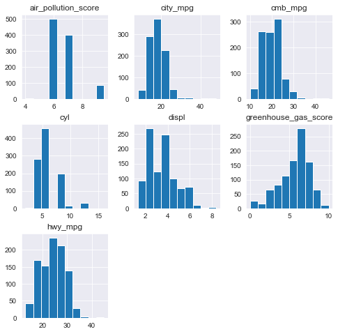

```python
# Distribution of features of 2008 dataframe
df_08.hist(figsize=(8,8));
```

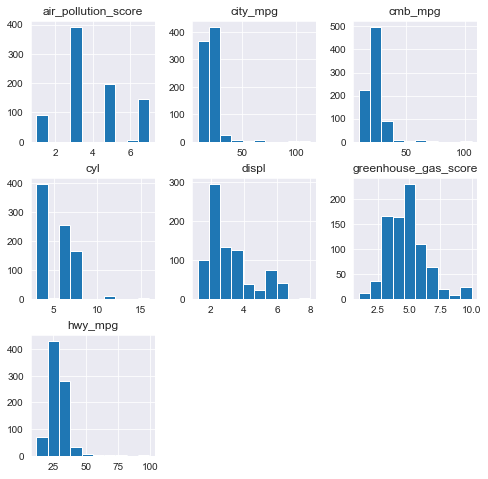

```python
# Distribution of features of 2018 dataframe
df_18.hist(figsize=(8,8));
```

**Correlation among features in 2008 and 2018 dataset**

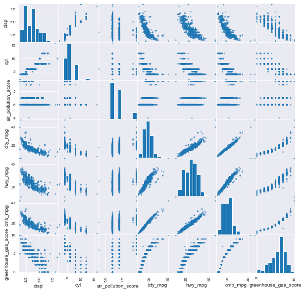

```python
# Correlation among features in 2008 dataset
pd.plotting.scatter_matrix(df_08,figsize=(10,10));
```

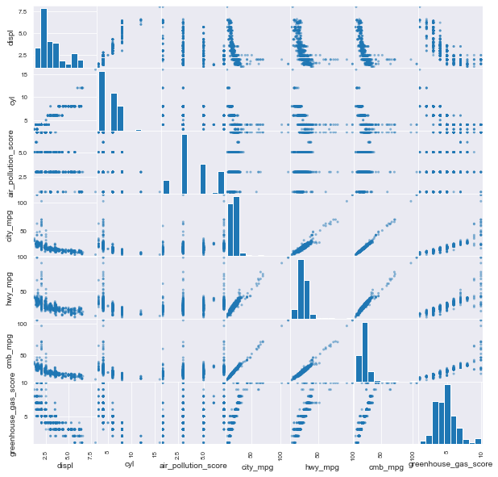

```python
#Correlation among features in 2018 dataset
pd.plotting.scatter_matrix(df_18,figsize=(10,10));
```

# Drawing Conclusions

### Q1: Are more unique models using alternative sources of fuel? By how much?

To answer this, I'll first look at what the sources of fuel are and which ones are alternative sources.

**Available alternative sources of fuel:**

- 2008: CNG and ethanol
- 2018: ethanol and electricity

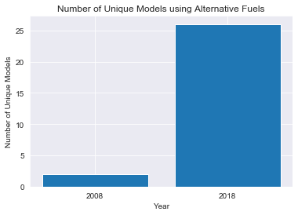

```python
#Plotting bar graph of the counts
plt.bar(["2008","2018"],[alt_08, alt_18])
plt.title('Number of Unique Models using Alternative Fuels')
plt.xlabel('Year')
plt.ylabel('Number of Unique Models');
```

**Insight:** Since 2008, the number of unique models using alternative sources of fuel increased by 24. I'll also look at the proportions.

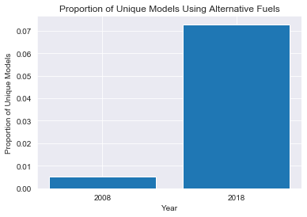

```python
#Plotting bar graph of the proportions
plt.bar(["2008", "2018"], [prop_08, prop_18])
plt.title("Proportion of Unique Models Using Alternative Fuels")
plt.xlabel("Year")
plt.ylabel("Proportion of Unique Models");
```

**Insight**: Thus the proportions are 0.0053 for 2008 and 0.072 for 2018

### Q2: How much have vehicle classes improved in fuel economy?

Let's look at the average fuel economy for each vehicle class for both years.

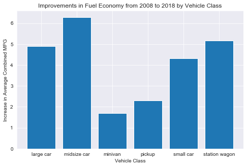

```python
# only plot the classes that exist in both years
inc.dropna(inplace=True)

plt.subplots(figsize=(8,5))
plt.bar(inc.index,inc)
plt.title('Improvements in Fuel Economy from 2008 to 2018 by Vehicle Class')
plt.xlabel('Vehicle Class')
plt.ylabel('Increase in Average Combined MPG');
```

**Insight:**

- Midsize cars have improved the most in fuel economy from 2008 to 2018 by 6.28 combined mpg
- The least improvement is shown by mini vans which is 1.68 combined mpg

## Q3: What are the characteristics of SmartWay vehicles? Have they changed over time?

This question can be analyzed by filtering each dataframe by SmartWay classification and exploring these datasets.

```python
# get all smartway vehicles in 2008 and explore
df_08.query('smartway == "yes"').describe()
```

|  | displ | cyl | air_pollution_score | city_mpg | hwy_mpg | cmb_mpg | greenhouse_gas_score |
| --- | --- | --- | --- | --- | --- | --- | --- |
| count | 380.000000 | 380.000000 | 380.000000 | 380.000000 | 380.000000 | 380.000000 | 380.000000 |
| mean | 2.602895 | 4.826316 | 7.365789 | 20.984211 | 28.413158 | 23.736842 | 6.868421 |
| std | 0.623436 | 1.002025 | 1.148195 | 3.442672 | 3.075194 | 3.060379 | 0.827338 |
| min | 1.300000 | 4.000000 | 6.000000 | 17.000000 | 22.000000 | 20.000000 | 6.000000 |
| 25% | 2.275000 | 4.000000 | 7.000000 | 19.000000 | 26.000000 | 22.000000 | 6.000000 |
| 50% | 2.400000 | 4.000000 | 7.000000 | 20.000000 | 28.000000 | 23.000000 | 7.000000 |
| 75% | 3.000000 | 6.000000 | 7.000000 | 22.000000 | 30.000000 | 25.000000 | 7.000000 |
| max | 5.000000 | 8.000000 | 9.500000 | 48.000000 | 45.000000 | 46.000000 | 10.000000 |

```python
# get all smartway vehicles in 2018 and explore
df_18.query('smartway in ["Yes","Elite"]').describe()
```

|  | displ | cyl | air_pollution_score | city_mpg | hwy_mpg | cmb_mpg | greenhouse_gas_score |
| --- | --- | --- | --- | --- | --- | --- | --- |
| count | 108.000000 | 108.000000 | 108.000000 | 108.000000 | 108.000000 | 108.000000 | 108.000000 |
| mean | 1.787963 | 3.935185 | 5.212963 | 34.907407 | 41.472222 | 37.361111 | 7.925926 |
| std | 0.408031 | 0.416329 | 1.798498 | 16.431982 | 13.095236 | 14.848429 | 1.197378 |
| min | 1.200000 | 3.000000 | 3.000000 | 25.000000 | 27.000000 | 26.000000 | 7.000000 |
| 25% | 1.500000 | 4.000000 | 3.000000 | 28.000000 | 36.000000 | 31.000000 | 7.000000 |
| 50% | 1.700000 | 4.000000 | 5.500000 | 28.500000 | 37.000000 | 32.000000 | 7.000000 |
| 75% | 2.000000 | 4.000000 | 7.000000 | 31.250000 | 40.250000 | 35.000000 | 9.000000 |
| max | 3.500000 | 6.000000 | 7.000000 | 113.000000 | 99.000000 | 106.000000 | 10.000000 |

**Insight:**

## Q4: What features are associated with better fuel economy?

```python
top_08 = df_08.query('cmb_mpg > cmb_mpg.mean()')
top_08.describe()
```

|  | displ | cyl | air_pollution_score | city_mpg | hwy_mpg | cmb_mpg | greenhouse_gas_score |
| --- | --- | --- | --- | --- | --- | --- | --- |
| count | 519.000000 | 519.000000 | 519.000000 | 519.000000 | 519.000000 | 519.000000 | 519.000000 |
| mean | 2.667823 | 4.890173 | 6.998073 | 20.317919 | 27.603083 | 22.992293 | 6.639692 |
| std | 0.665551 | 1.034856 | 1.159565 | 3.198257 | 3.051120 | 2.926371 | 0.804935 |
| min | 1.300000 | 4.000000 | 4.000000 | 17.000000 | 20.000000 | 20.000000 | 6.000000 |
| 25% | 2.300000 | 4.000000 | 6.000000 | 18.000000 | 25.000000 | 21.000000 | 6.000000 |
| 50% | 2.500000 | 4.000000 | 7.000000 | 20.000000 | 27.000000 | 22.000000 | 6.000000 |
| 75% | 3.000000 | 6.000000 | 7.000000 | 21.000000 | 29.000000 | 24.000000 | 7.000000 |
| max | 6.000000 | 8.000000 | 9.500000 | 48.000000 | 45.000000 | 46.000000 | 10.000000 |

```python
top_18 = df_18.query('cmb_mpg > cmb_mpg.mean()')
top_18.describe()
```

|  | displ | cyl | air_pollution_score | city_mpg | hwy_mpg | cmb_mpg | greenhouse_gas_score |
| --- | --- | --- | --- | --- | --- | --- | --- |
| count | 328.000000 | 328.000000 | 328.000000 | 328.000000 | 328.000000 | 328.000000 | 328.000000 |
| mean | 1.964329 | 4.021341 | 4.856707 | 27.472561 | 35.304878 | 30.411585 | 6.329268 |
| std | 0.398593 | 0.465477 | 1.860802 | 11.033692 | 9.024857 | 10.081539 | 1.410358 |
| min | 1.200000 | 3.000000 | 1.000000 | 21.000000 | 27.000000 | 25.000000 | 4.000000 |
| 25% | 1.600000 | 4.000000 | 3.000000 | 23.000000 | 31.000000 | 26.000000 | 5.000000 |
| 50% | 2.000000 | 4.000000 | 5.000000 | 25.000000 | 33.000000 | 28.000000 | 6.000000 |
| 75% | 2.000000 | 4.000000 | 7.000000 | 28.000000 | 36.000000 | 31.000000 | 7.000000 |
| max | 3.500000 | 6.000000 | 7.000000 | 113.000000 | 99.000000 | 106.000000 | 10.000000 |

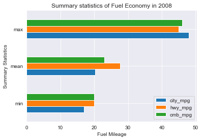

```python
desc_08 = top_08.describe().loc[['min','mean', 'max']]
ax = desc_08.iloc[: ,3:6].plot(kind='barh')
ax.set(xlabel = 'Fuel Mileage', ylabel='Summary Statistics', title='Summary statistics of Fuel Economy in 2008');
```

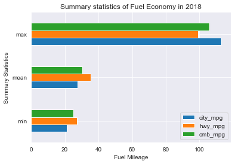

```python
desc_18 = top_18.describe().loc[['min','mean', 'max']]
ax = desc_18.iloc[: ,3:6].plot(kind='barh');
ax.set(xlabel = 'Fuel Mileage', ylabel='Summary Statistics', title='Summary statistics of Fuel Economy in 2018');
```

**Insights:**

The above combination of statistics suggest a better fuel ecomomy

## Results with Merged Dataset

### Q5: For all of the models that were produced in 2008 that are still being produced now, how much has the mpg improved and which vehicle improved the most?

```python
model_mpg[model_mpg['mpg_change'] == max_change]
```

| model | cmb_mpg_2008 | cmb_mpg | mpg_change |
| --- | --- | --- | --- |
| VOLVO XC 90 | 15.666667 | 32.2 | 16.533333 |

**Insight**: Thus, the model improved which has improved the most from 2008 to 2018 is VOLVO XC 90 and the improvement is 16.53 mpg.

```python
model_mpg.loc[idx]
```

```
cmb_mpg_2008    15.666667
cmb_mpg         32.200000
mpg_change      16.533333
Name: VOLVO XC 90, dtype: float64
```

This shows that the combined mpg was 15.6 in 2008 and increased to 32.2 in 2018 which gives a max change of 16.53.

## Conclusion:

Thus, I have assessed, cleaned and explored this dataset to draw conclusions about the following questions:

**1. Are more unique models using alternative sources of fuel? By how much?**

- Available alternative sources of fuel are CNG and ethanol in 2008 and ethanol and electricity in 2018
- The proportions are 0.0053 for 2008 and 0.072 for 2018

**2. How much have vehicle classes improved in fuel economy?**

- Midsize cars have improved the most in fuel economy from 2008 to 2018 by 6.28 combined mpg
- Least improvement is shown by mini vans which is 1.68 combined mpg

**3. What are the characteristics of SmartWay vehicles? Have they changed over time?**

The above combination of statistics suggest a better fuel ecomomy

**5. For all of the models that were produced in 2008 that are still being produced now, how much has the mpg improved and which vehicle improved the most?**

- The model improved which has improved the most from 2008 to 2018 is VOLVO XC 90 and the improvement is 16.53 mpg